# 2 Data Screening

Rushabh Barbhaya

2020-11-13

## Data Screening Class Assignment

Download the data screening file to analyze. You want to screen the whole dataset at once to look for issues, since all the variables will be used in several different hypotheses. Import the data below.

```r
df <- read.csv("assignment_data_screen.csv")
head(df)
```

```
##   Participant_ID q1 q2 q3 q4 q5 q6 q7 q8 q9 q10 q11
## 1             85  2  1  5  1  2  5  1  2  3   4   1
## 2            327  6  5  3  5  5  3  6  1  3   3   6
## 3            606  4  5  4  4  4  5  3  1  1   1   4
## 4             31  4  4  6  6  6  1  2  2  3   4   4
## 5            140  6  6  5  6  5  6  6  5  6   6   6
## 6            777  5  6  4  1  4  6  5  5  5   5   6
```

```r
str(df)
```

```
## 'data.frame':    797 obs. of  12 variables:
##  $ Participant_ID: int  85 327 606 31 140 777 342 16 696 320 ...
##  $ q1            : int  2 6 4 4 6 5 6 2 6 3 ...
##  $ q2            : int  1 5 5 4 6 6 6 5 6 5 ...
##  $ q3            : int  5 3 4 6 5 4 6 2 3 1 ...
##  $ q4            : int  1 5 4 6 6 1 6 5 6 5 ...
##  $ q5            : int  2 5 4 6 5 4 NA 3 1 2 ...
##  $ q6            : int  5 3 5 1 6 6 NA 1 6 5 ...
##  $ q7            : int  1 6 3 2 6 5 NA 6 5 2 ...
##  $ q8            : int  2 1 1 2 5 5 NA 2 5 3 ...
##  $ q9            : int  3 3 1 3 6 5 NA 2 4 1 ...
##  $ q10           : int  4 3 1 4 6 5 NA 2 4 1 ...
##  $ q11           : int  1 6 4 4 6 6 NA 2 5 1 ...
```

Study: This dataset includes a male body dissatisfaction scale with the following questions:

1. I think my body should be leaner
2. I am concerned that my stomach is too flabby
3. I feel dissatisfied with my overall body build
4. I think I have too much fat on my body
5. I think my abs are not thin enough
6. I feel satisfied with the size and shape of my body
7. Has eating sweets, cakes, or other high calorie food made you feel fat or weak?
8. Have you felt excessively large and rounded (i.e., fat)?
9. Have you felt ashamed of your body size or shape?
10. Has seeing your reflection (e.g., in a mirror or window) made you feel badly about your size or shape?
11. Have you been so worried about your body size or shape that you have been feeling that you ought to diet?

## Check the data for the following:

### Accuracy:

Check the data for out of range scores. The scale ranges from 1 (*never*) to 6 (*always*). Use the `summary()` function to inspect the scores.

```r
summary(df)
```

```
##  Participant_ID        q1              q2              q3
##  Min.   :  1.0   Min.   :1.000   Min.   :1.000   Min.   :1.000
##  1st Qu.:212.0   1st Qu.:2.000   1st Qu.:2.000   1st Qu.:2.000
##  Median :423.0   Median :3.000   Median :4.000   Median :3.000
##  Mean   :422.3   Mean   :3.393   Mean   :3.556   Mean   :3.227
##  3rd Qu.:634.0   3rd Qu.:4.000   3rd Qu.:5.000   3rd Qu.:4.000
##  Max.   :841.0   Max.   :6.000   Max.   :6.000   Max.   :6.000
##                                  NA's   :2       NA's   :4
##        q4              q5              q6              q7
##  Min.   :1.000   Min.   :1.000   Min.   :1.000   Min.   :1.000
##  1st Qu.:2.000   1st Qu.:2.000   1st Qu.:3.000   1st Qu.:2.000
##  Median :3.000   Median :3.000   Median :4.000   Median :3.000
##  Mean   :3.335   Mean   :3.204   Mean   :3.823   Mean   :3.196
##  3rd Qu.:5.000   3rd Qu.:4.000   3rd Qu.:5.000   3rd Qu.:4.250
##  Max.   :6.000   Max.   :6.000   Max.   :6.000   Max.   :6.000
##  NA's   :2       NA's   :9       NA's   :5       NA's   :5
##        q8              q9             q10             q11
##  Min.   :1.000   Min.   :1.000   Min.   :1.000   Min.   :1.000
##  1st Qu.:1.000   1st Qu.:2.000   1st Qu.:2.000   1st Qu.:1.000
##  Median :3.000   Median :3.000   Median :3.000   Median :3.000
##  Mean   :2.789   Mean   :3.003   Mean   :2.985   Mean   :2.931
##  3rd Qu.:4.000   3rd Qu.:4.000   3rd Qu.:4.000   3rd Qu.:4.000
##  Max.   :6.000   Max.   :6.000   Max.   :6.000   Max.   :6.000
##  NA's   :5       NA's   :6       NA's   :4       NA's   :4
```

QUESTION: What are the problems you see in the dataset?  
ANSWER: NA values

### Missing data:

QUESTION: Using the summary function from above, what type of missing data do you appear to have? ANSWER: Missing values or incomplete survey

Calculate the missing scores by participant (rows), showing the final missing percentages using the `table()` function.

```r
perMiss = function(x) {
  sum(is.na(x))/length(x) * 100
}
missing = apply(df[,-1], 1, perMiss)
table(missing)
```

```
## missing
##                0 9.09090909090909 63.6363636363636 81.8181818181818
##              780               13                2                1
## 90.9090909090909
##                1
```

Exclude all participants with more than 5% missing data.

```r
noMiss = subset(df, missing <= 5)
summary(noMiss)
```

```
##  Participant_ID        q1             q2              q3              q4
##  Min.   :  1.0   Min.   :1.00   Min.   :1.000   Min.   :1.000   Min.   :1.000
##  1st Qu.:212.8   1st Qu.:2.00   1st Qu.:2.000   1st Qu.:2.000   1st Qu.:2.000
##  Median :426.5   Median :3.00   Median :4.000   Median :3.000   Median :3.000
##  Mean   :423.8   Mean   :3.39   Mean   :3.562   Mean   :3.231   Mean   :3.341
##  3rd Qu.:636.2   3rd Qu.:4.00   3rd Qu.:5.000   3rd Qu.:4.000   3rd Qu.:5.000
##  Max.   :841.0   Max.   :6.00   Max.   :6.000   Max.   :6.000   Max.   :6.000
##        q5              q6              q7              q8              q9
##  Min.   :1.000   Min.   :1.000   Min.   :1.000   Min.   :1.000   Min.   :1.00
##  1st Qu.:2.000   1st Qu.:3.000   1st Qu.:2.000   1st Qu.:1.000   1st Qu.:2.00
##  Median :3.000   Median :4.000   Median :3.000   Median :3.000   Median :3.00
##  Mean   :3.194   Mean   :3.824   Mean   :3.197   Mean   :2.801   Mean   :3.01
##  3rd Qu.:4.000   3rd Qu.:5.000   3rd Qu.:4.250   3rd Qu.:4.000   3rd Qu.:4.00
##  Max.   :6.000   Max.   :6.000   Max.   :6.000   Max.   :6.000   Max.   :6.00
##       q10             q11
##  Min.   :1.000   Min.   :1.000
##  1st Qu.:2.000   1st Qu.:1.000
##  Median :3.000   Median :3.000
##  Mean   :2.992   Mean   :2.935
##  3rd Qu.:4.000   3rd Qu.:4.000
##  Max.   :6.000   Max.   :6.000
```

```r
colMissing = apply(df[,-1], 2, perMiss)
table(colMissing)
```

```
## colMissing
##                 0 0.250941028858218 0.501882057716437 0.627352572145546
##                 1                 2                 3                 3
## 0.752823086574655  1.12923462986198
##                 1                 1
```

```r
colMis = subset(df, missing <= 5)
```

### Outliers:

Calculate Mahalanobis distance scores for your data.

```r
mahal = mahalanobis(noMiss[,-1],
                    colMeans(noMiss[,-1]),
                    cov(noMiss[,-1]))
ncol(noMiss[-1])
```

```
## [1] 11
```

```r
cutoff = qchisq(1-.001, ncol(noMiss[-1]))
cutoff
```

```
## [1] 31.26413
```

```r
table(mahal < cutoff)
```

```
##
## FALSE  TRUE
##    16   764
```

QUESTION: What is the *df* for your cut off score? ANSWER: 11

QUESTION: What is the cut off score? ANSWER: 31.26413

QUESTION: How many outliers did you have? ANSWER:16

Exclude the outliers, if you have any.

```r
noOut = subset(noMiss, mahal < cutoff)
cat("Whole Dataset Dim -->",dim(df))
```

```
## Whole Dataset Dim --> 797 12
```

```r
cat("Missing Dataset Dim -->",dim(noMiss))
```

```
## Missing Dataset Dim --> 780 12
```

```r
cat("No Outliers Dataset Dim -->",dim(noOut))
```

```
## No Outliers Dataset Dim --> 764 12
```

### Additivity:

Include a depiction of the correlation between scale items with `corplot`.

```r
correlation = cor(noOut[,-1])
symnum(correlation)
```

```
##     q1 q2 q3 q4 q5 q6 q7 q8 q9 q10 q11
## q1  1
## q2  ,  1
## q3  .  ,  1
## q4  ,  +  ,  1
## q5  ,  ,  .  ,  1
## q6  .  .  .  .  .  1
## q7  .  .  .  .  .     1
## q8  ,  ,  ,  +  ,  .  ,  1
## q9  ,  ,  ,  ,  .  .  ,  +  1
## q10 ,  ,  ,  ,  ,  .  ,  ,  +  1
## q11 ,  ,  ,  ,  ,  .  ,  +  ,  ,   1
## attr(,"legend")
## [1] 0 ' ' 0.3 '.' 0.6 ',' 0.8 '+' 0.9 '*' 0.95 'B' 1
```

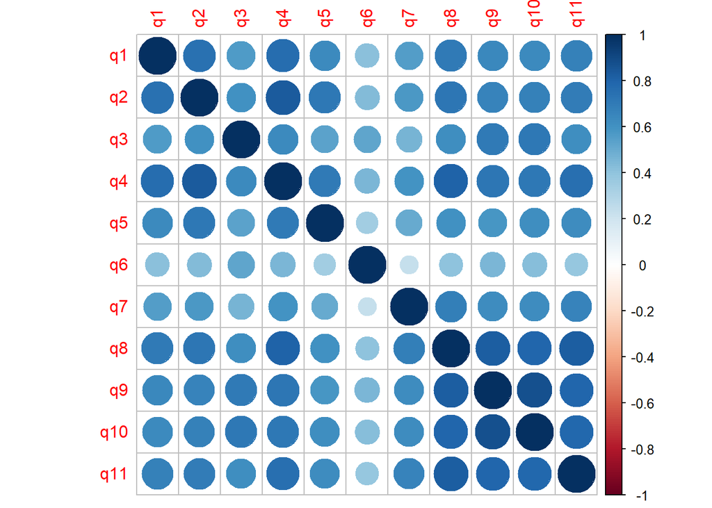

```r
library(corrplot)
corrplot(correlation)
```

### Normality:

Include the multivariate normality histogram.

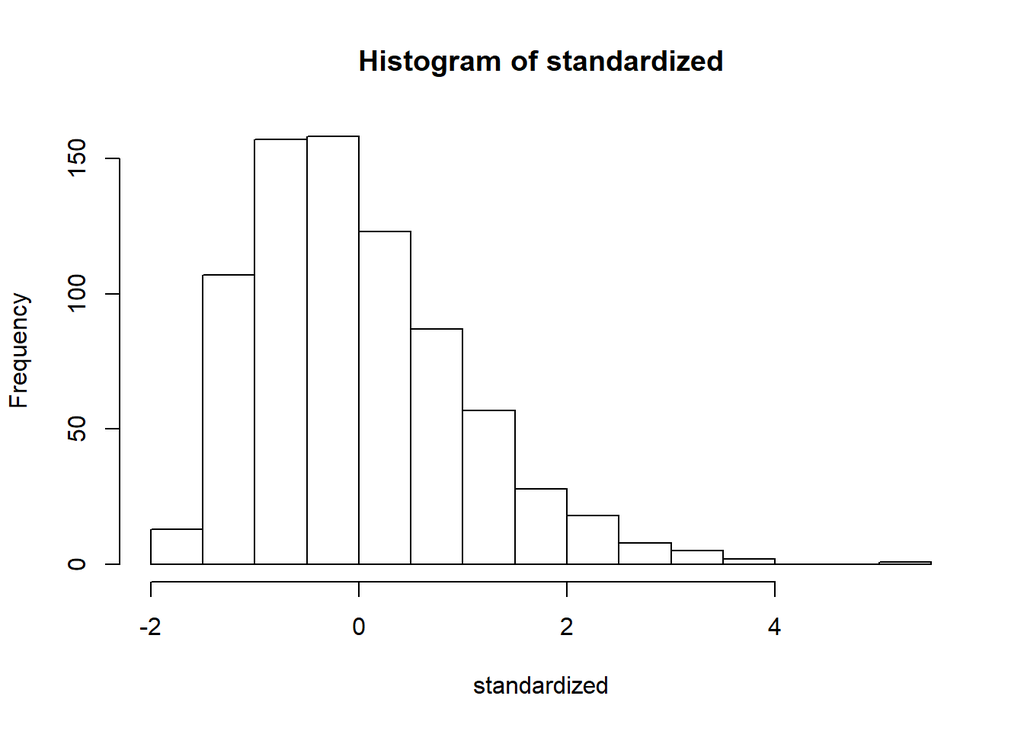

```r
random = rchisq(nrow(noOut), 7)
fake = lm(random ~., data = noOut[,-1])
standardized = rstudent(fake)
fitted = scale(fake$fitted.values)
hist(standardized)
```

QUESTION: Interpret the graph. Does it indicate multivariate normality? ANSWER: Yes, mostly, slight skew.

### Linearity:

Include the multivariate QQ plot.

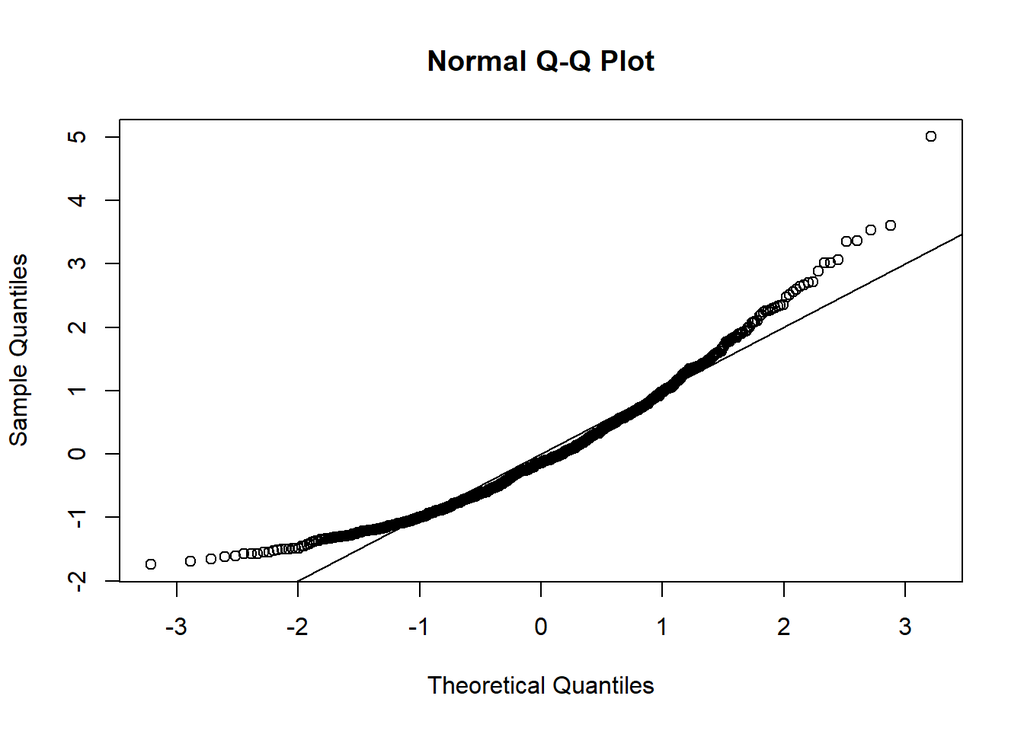

```r
qqnorm(standardized)
abline(0,1)
```

QUESTION: Interpret the graph. Does it indicate multivariate linearity? ANSWER: Mainly, Yes. Tails are a bit out far from the normal.

### Homogeneity/Homoscedasticity:

Include the multivariate residuals plot.

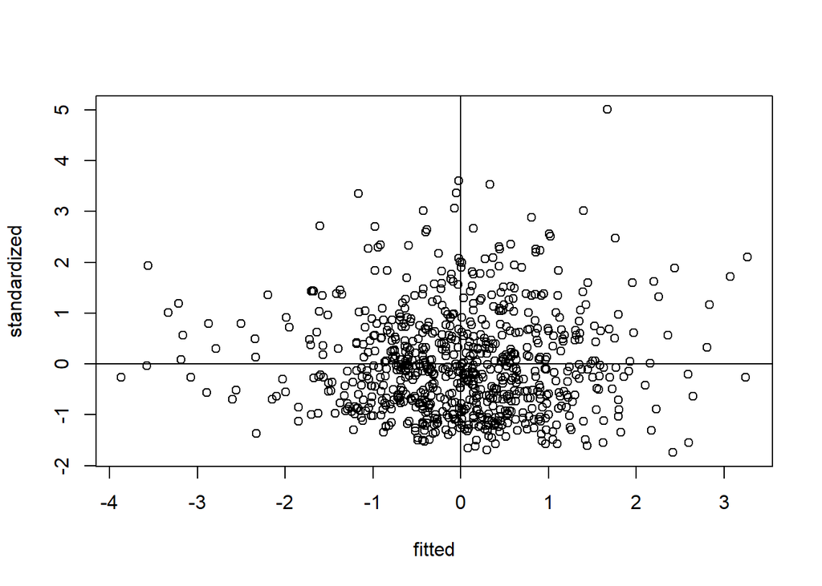

```r
plot(fitted, standardized)
abline(0,0)
abline(v = 0)
```